# Living Standards in the 19th Century: Evidence from the SR1

Jim Irwin and Jesse McDevitt-Irwin

19 September, 2020

# France: 1850-1900

Previous work has suggested small improvements in health in France from 1850-1880, and then larger improvements from 1880-1900. Height data shows no change between cohorts born in 1850 and 1880, slow improvement from 1880-1910, and fast improvement after World War Two (Weir 1997). Male height has a clear connection to maternal-infant health, as in-utero nutrition play a large role in determining adult health outcomes.[^1]

Before 1900, urban mortality was greater than rural, but the introduction sewers and water treatment was lead to a shrinking of this urban-rural gap (Preston and Van de Walle 1978; Kesztenbaum and Rosenthal 2017).

From these two measures, we would expect the SR1 to weakly increase from 1850-1900, especially in Paris and other large urban areas. We would also expect the SR1 to be higher in rural areas, reflecting lower infant mortality from better sanitary conditions and nutrition.

In figure 1, we split the French *départments* into three groups: rural (*départments* without a city over the size of 100,00), urban (*départments* with at least one city of population between 100,000 and 500,000), and metropolitan (*départments* with a city of over 500,000). The metropolitan group is just Paris, while the urban group includes the *départments* of Marseille, Lyon and, depending on the year, certain other regional cities (e.g. Bordeax, Lille or Nice). The rural group includes the rest of the *départments* and represents the majority of the population throughout the period.

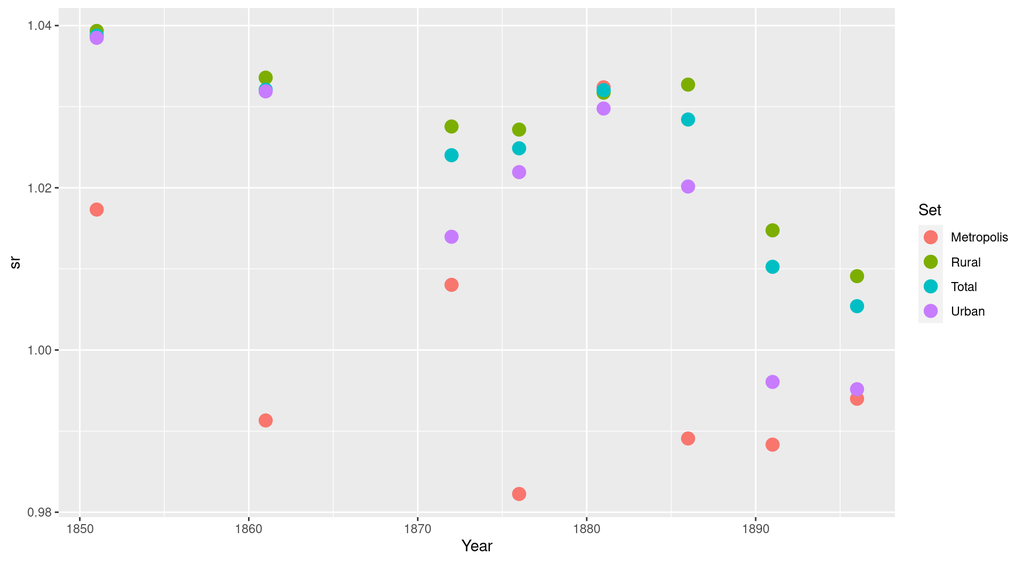

We see that the SR1 in Paris was consistently lower than in rural areas or smaller cities,[^2] as would be expected by infant mortality figures. However, the SR1 of Paris did not improve after 1881, in contrast to the findings of previous authors mentioned above. This previous work, however, focuses on mortality across the life cycle, whereas the SR1 captures maternal stress and infant mortality. Thus, it could be that maternal stress was increasing, off-setting the general benefits of improved sanitation. Contemporary literature, such as Emile Zola’s *L’Assommoir*, provide suggestive evidence of the extreme stress pervaded the life of working-class Parisian women.

Comparing across countries, the SR1 suggests that in 1850 the French population enjoyed material living conditions (SR1=104 ) substantially better than those in England and Wales (SR1=100), but similar to those of Ireland and Scotland. However, the sex-ratio declined from 1880-1900, suggesting declining maternal-infant health. Such a finding is in direct contrast to previous studies (Weir 1997; Kesztenbaum and Rosenthal 2017). For now, it is only suggestive, as there are some irregularities with the sex-ratios from published census data.[^3] Further research is needed to confirm this anamoly, but the evidence suggests that the second industrial revolution may have had larger social costs than previously thought.

# References

Almond, Douglas, and Janet Currie. 2011. “Killing Me Softly: The Fetal Origins Hypothesis.” *Journal of Economic Perspectives* 25 (3): 153–72.

Kesztenbaum, Lionel, and Jean-Laurent Rosenthal. 2017. “Sewers’ Diffusion and the Decline of Mortality: The Case of Paris, 18801914.” *Journal of Urban Economics* 98: 174–86.

Preston, Samuel H., and Etienne Van de Walle. 1978. “Urban French Mortality in the Nineteenth Century.” *Population Studies* 32 (2): 275–97.

Weir, David. 1997. “Economic Welfare and Physical Well-Being in France, 1750-1990.” *Health and Welfare During Industrialization*, January, 161–200.

[^1]: For an overview of the literature from an applied economics perspective, see Almond et. al. (2011).
[^2]: Except for the year of 1881where the SR1 in Paris is nearly identical to the SR1 in the rural part of the sample. This seems highly improbable given the stable ranking of all other years.
[^3]: See footnote 2.